# Natural Language Processing - Twitter Analysis

## Problem Statement

### Context

With 330 million monthly active users, Twitter enables businesses to reach a wide audience and engage directly with customers. However, the volume of information makes it challenging for brands to quickly identify negative mentions that could impact their reputation.

As a result, sentiment analysis, which monitors emotions in social media conversations, has become an essential strategy in social media marketing.

Monitoring customer sentiment on Twitter helps companies understand their audience, stay informed about brand and competitor discussions, and identify emerging industry trends.

### Objective

This project focuses on analyzing customer tweets about U.S. airlines and categorizing their sentiments as positive, neutral, or negative.

### Data Description

A sentiment analysis job about the problems of each major U.S. airline. Twitter data was scraped from February of 2015 and contributors were asked to first classify positive, negative, and neutral tweets, followed by categorizing negative reasons (such as "late flight" or "rude service").

### Data Dictionary

- tweet_id - A unique identifier for each tweet
- airline_sentiment - The sentiment label of the tweet, such as positive, negative, or neutral
- airline_sentiment_confidence - The confidence level associated with the sentiment label
- negativereason - A category indicating the reason for negative sentiment
- negativereason_confidence - The confidence level associated with the negative reason
- airline - The airline associated with the tweet
- airline_sentiment_gold - Gold standard sentiment label
- name - The username of the tweet author
- negativereason_gold - Corrected gold standard label for the reason behind a negative tweet
- retweet_count - The number of times the tweet has been retweeted
- text - The actual text content of the tweet.
- tweet_coord - Coordinates of the tweet
- tweet_created - The timestamp when the tweet was created
- tweet_location - The location mentioned in the tweet
- user_timezone - The timezone of the tweet author

## Importing necessary libraries

```python
!pip install wordcloud
```

```python
# Data handling
import pandas as pd
import numpy as np

# Exploratory Data Analysis
import matplotlib.pyplot as plt
import seaborn as sns

# Text pre-processing
import re, string
from wordcloud import WordCloud, STOPWORDS
from bs4 import BeautifulSoup
import nltk
from nltk.corpus import stopwords
from nltk.tokenize import word_tokenize
from nltk.stem.wordnet import WordNetLemmatizer

# Feature extraction
from sklearn.feature_extraction.text import CountVectorizer, TfidfVectorizer

# Model building & evaluation

from sklearn.model_selection import train_test_split, cross_val_score, StratifiedKFold
from sklearn.ensemble import RandomForestClassifier
from sklearn.metrics import accuracy_score, classification_report, confusion_matrix

# NLTK resources

nltk.download('punkt')
nltk.download('wordnet')
nltk.download('stopwords')
nltk.download('omw-1.4')
```

```
True
```

## Loading the dataset

```python
# Read the data
tweets = pd.read_csv("tweets.csv")

# Create a copy of the dataset for analysis
df = tweets.copy()
```

## Data Overview

The initial steps to get an overview of any dataset is to:

- Observe the first few rows of the dataset, to check whether the dataset has been loaded properly or not
- Get information about the number of rows and columns in the dataset
- Find out the data types of the columns to ensure that data is stored in the preferred format and the value of each property is as expected.

```python
# Observe the first few rows

print("First 5 rows of the dataset:")
display(df.head())
```

```
First 5 rows of the dataset:
```

|  | tweet_id | airline_sentiment | airline_sentiment_confidence | negativereason | negativereason_confidence | airline | airline_sentiment_gold | name | negativereason_gold | retweet_count | text | tweet_coord | tweet_created | tweet_location | user_timezone |
| --- | --- | --- | --- | --- | --- | --- | --- | --- | --- | --- | --- | --- | --- | --- | --- |
| 0 | 570306133677760513 | neutral | 1.0000 | NaN | NaN | Virgin America | NaN | cairdin | NaN | 0 | @VirginAmerica What @dhepburn said. | NaN | 2015-02-24 11:35:52 -0800 | NaN | Eastern Time (US & Canada) |
| 1 | 570301130888122368 | positive | 0.3486 | NaN | 0.0000 | Virgin America | NaN | jnardino | NaN | 0 | @VirginAmerica plus you've added commercials t... | NaN | 2015-02-24 11:15:59 -0800 | NaN | Pacific Time (US & Canada) |
| 2 | 570301083672813571 | neutral | 0.6837 | NaN | NaN | Virgin America | NaN | yvonnalynn | NaN | 0 | @VirginAmerica I didn't today... Must mean I n... | NaN | 2015-02-24 11:15:48 -0800 | Lets Play | Central Time (US & Canada) |
| 3 | 570301031407624196 | negative | 1.0000 | Bad Flight | 0.7033 | Virgin America | NaN | jnardino | NaN | 0 | @VirginAmerica it's really aggressive to blast... | NaN | 2015-02-24 11:15:36 -0800 | NaN | Pacific Time (US & Canada) |
| 4 | 570300817074462722 | negative | 1.0000 | Can't Tell | 1.0000 | Virgin America | NaN | jnardino | NaN | 0 | @VirginAmerica and it's a really big bad thing... | NaN | 2015-02-24 11:14:45 -0800 | NaN | Pacific Time (US & Canada) |

```python
# Get number of rows and columns

print("Shape of the dataset (Rows, Columns):",df.shape)
```

```
Shape of the dataset (Rows, Columns): (14640, 15)
```

```python
# Check the data types and the count of non null values

print("Information about the dataset:",df.info())
```

```
<class 'pandas.core.frame.DataFrame'>
RangeIndex: 14640 entries, 0 to 14639
Data columns (total 15 columns):
 #   Column                        Non-Null Count  Dtype
---  ------                        --------------  -----
 0   tweet_id                      14640 non-null  int64
 1   airline_sentiment             14640 non-null  object
 2   airline_sentiment_confidence  14640 non-null  float64
 3   negativereason                9178 non-null   object
 4   negativereason_confidence     10522 non-null  float64
 5   airline                       14640 non-null  object
 6   airline_sentiment_gold        40 non-null     object
 7   name                          14640 non-null  object
 8   negativereason_gold           32 non-null     object
 9   retweet_count                 14640 non-null  int64
 10  text                          14640 non-null  object
 11  tweet_coord                   1019 non-null   object
 12  tweet_created                 14640 non-null  object
 13  tweet_location                9907 non-null   object
 14  user_timezone                 9820 non-null   object
dtypes: float64(2), int64(2), object(11)
memory usage: 1.7+ MB
Information about the dataset: None
```

```python
# Check for missing values

print("Missing values in each column:")
print(df.isnull().sum())
```

```
Missing values in each column:
tweet_id                            0
airline_sentiment                   0
airline_sentiment_confidence        0
negativereason                   5462
negativereason_confidence        4118
airline                             0
airline_sentiment_gold          14600
name                                0
negativereason_gold             14608
retweet_count                       0
text                                0
tweet_coord                     13621
tweet_created                       0
tweet_location                   4733
user_timezone                    4820
dtype: int64
```

## Exploratory Data Analysis

- EDA is an important part of any project involving data.
- It is important to investigate and understand the data better before building a model with it.
- A few questions have been mentioned below which will help you approach the analysis in the right manner and generate insights from the data.
- A thorough analysis of the data, in addition to the questions mentioned below, should be done.

**Questions**:

- What is the percentage of tweets for each airline?
- What is the distribution of sentiments across all the tweets?
- What is the distribution of sentiments for each airline?
- What does the plot of negative reasons indicate?
- How does a wordcloud appear for negative tweets?
- How does a wordcloud appear for positive tweets?
- What are insights observed from EDA?

```python
# summary of all numerical variables
df.describe().T
```

|  | count | mean | std | min | 25% | 50% | 75% | max |
| --- | --- | --- | --- | --- | --- | --- | --- | --- |
| tweet_id | 14640.0 | 5.692184e+17 | 7.791112e+14 | 5.675883e+17 | 5.685592e+17 | 5.694779e+17 | 5.698905e+17 | 5.703106e+17 |
| airline_sentiment_confidence | 14640.0 | 9.001689e-01 | 1.628300e-01 | 3.350000e-01 | 6.923000e-01 | 1.000000e+00 | 1.000000e+00 | 1.000000e+00 |
| negativereason_confidence | 10522.0 | 6.382983e-01 | 3.304398e-01 | 0.000000e+00 | 3.606000e-01 | 6.706000e-01 | 1.000000e+00 | 1.000000e+00 |
| retweet_count | 14640.0 | 8.265027e-02 | 7.457782e-01 | 0.000000e+00 | 0.000000e+00 | 0.000000e+00 | 0.000000e+00 | 4.400000e+01 |

```python
# show summary of all categorical variables
df.describe(include=['object']).T
```

|  | count | unique | top | freq |
| --- | --- | --- | --- | --- |
| airline_sentiment | 14640 | 3 | negative | 9178 |
| negativereason | 9178 | 10 | Customer Service Issue | 2910 |
| airline | 14640 | 6 | United | 3822 |
| airline_sentiment_gold | 40 | 3 | negative | 32 |
| name | 14640 | 7701 | JetBlueNews | 63 |
| negativereason_gold | 32 | 13 | Customer Service Issue | 12 |
| text | 14640 | 14427 | @united thanks | 6 |
| tweet_coord | 1019 | 832 | [0.0, 0.0] | 164 |
| tweet_created | 14640 | 14247 | 2015-02-24 09:54:34 -0800 | 5 |
| tweet_location | 9907 | 3081 | Boston, MA | 157 |
| user_timezone | 9820 | 85 | Eastern Time (US & Canada) | 3744 |

```python
# Percentage of tweets per airline

airline_counts = df['airline'].value_counts(normalize=True) * 100
print("Percentage of tweets per airline:")
print(airline_counts)
```

```
Percentage of tweets per airline:
United            26.106557
US Airways        19.897541
American          18.845628
Southwest         16.530055
Delta             15.177596
Virgin America     3.442623
Name: airline, dtype: float64
```

- Tweets concerning United Airlines received the most tweets (26.11% of all tweets)
- Tweets concerning Virigin America received the fewest tweets (3.44% of all tweets)

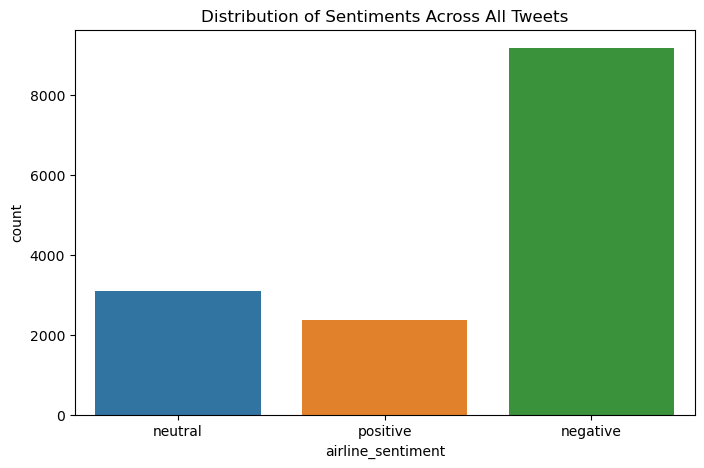

```python
# Distribution of Sentiments across all tweets

plt.figure(figsize=(8,5))
sns.countplot(data=df, x='airline_sentiment')
plt.title("Distribution of Sentiments Across All Tweets")
plt.show()
```

- The dataset shows a strong class imbalance, with nearly four times more negative tweets than positive ones and about three times more than neutral ones, which may create a bias in the classification model.

```python
# Distribution of Sentiments across all tweets

df.groupby('airline')['airline_sentiment'].value_counts()
```

```
airline         airline_sentiment
American        negative             1960
                neutral               463
                positive              336
Delta           negative              955
                neutral               723
                positive              544
Southwest       negative             1186
                neutral               664
                positive              570
US Airways      negative             2263
                neutral               381
                positive              269
United          negative             2633
                neutral               697
                positive              492
Virgin America  negative              181
                neutral               171
                positive              152
Name: airline_sentiment, dtype: int64
```

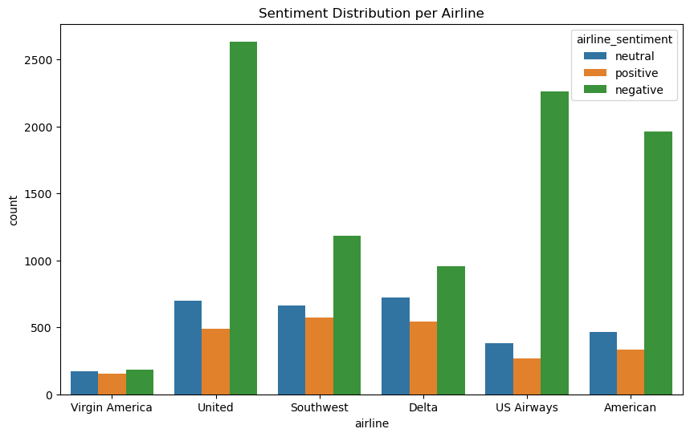

```python
# Distribution of Sentiment per Airline

plt.figure(figsize=(10,6))
sns.countplot(data=df, x='airline', hue='airline_sentiment')
plt.title("Sentiment Distribution per Airline")
plt.show()
```

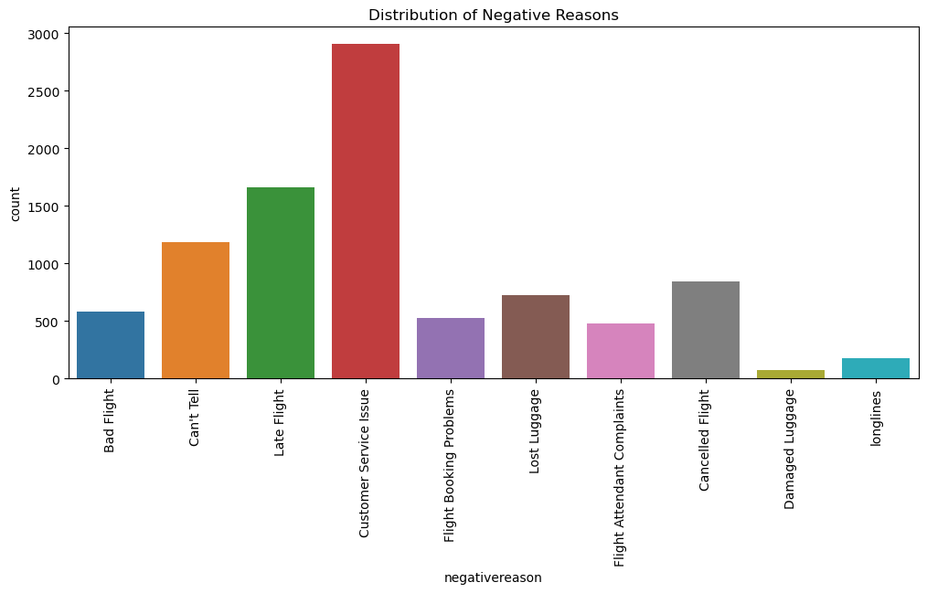

```python
# Distribution of Negative Reasons

plt.figure(figsize=(12,5))
sns.countplot(data=df[df['airline_sentiment']=='negative'], x='negativereason')
plt.title("Distribution of Negative Reasons")
plt.xticks(rotation=90)
plt.show()
```

- From the chart, we can see that customer service issues are the leading cause of negative tweets followed by Late Flight and Can't Tell.

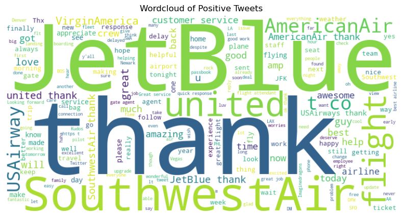

```python
# Wordcloud for positive tweets

pos_text = " ".join(df[df['airline_sentiment']=='positive']['text'])
wordcloud_pos = WordCloud(width=800, height=400, background_color='white', stopwords=STOPWORDS).generate(pos_text)

plt.figure(figsize=(10,5))
plt.imshow(wordcloud_pos, interpolation='bilinear')
plt.axis('off')
plt.title("Wordcloud of Positive Tweets")
plt.show()
```

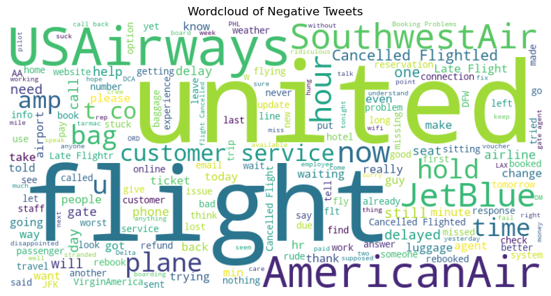

```python
# Wordcloud for negative tweets

neg_text = " ".join(df[df['airline_sentiment']=='negative']['text'])
wordcloud_neg = WordCloud(width=800, height=400, background_color='white', stopwords=STOPWORDS).generate(neg_text)

plt.figure(figsize=(10,5))
plt.imshow(wordcloud_neg, interpolation='bilinear')
plt.axis('off')
plt.title("Wordcloud of Negative Tweets")
plt.show()
```

- United is a very common word in both positive and negative tweets, indicating that this word will likely not contribute to a classification model
- As expected from the negative reasons shown above, words like flight, USAirways, AmericanAir, cancelled were the most commonly used in negative tweets

## Understand the Columns

- Drop all unnecessary columns and check the data frame

```python
# Check the column names

print("Columns in the dataset:")
print(df.columns)
column_list = df.columns.to_list()
```

```
Columns in the dataset:
Index(['tweet_id', 'airline_sentiment', 'airline_sentiment_confidence',
       'negativereason', 'negativereason_confidence', 'airline',
       'airline_sentiment_gold', 'name', 'negativereason_gold',
       'retweet_count', 'text', 'tweet_coord', 'tweet_created',
       'tweet_location', 'user_timezone'],
      dtype='object')
```

```python
# columns used for model building
columns = ['text','airline_sentiment']

# columns to be dropped
drop_columns = [col for col in column_list if col not in columns]
print(drop_columns)
```

```
['tweet_id', 'airline_sentiment_confidence', 'negativereason', 'negativereason_confidence', 'airline', 'airline_sentiment_gold', 'name', 'negativereason_gold', 'retweet_count', 'tweet_coord', 'tweet_created', 'tweet_location', 'user_timezone']
```

```python
# drop all other columns except “text” and “airline_sentiment” and confirm new shape of the dataset

df_model = df.drop(columns = drop_columns)
df_model.shape

# print head of new dataset with full data frame info

pd.set_option('display.max_colwidth', None)
df_model.head()
```

|  | airline_sentiment | text |
| --- | --- | --- |
| 0 | neutral | @VirginAmerica What @dhepburn said. |
| 1 | positive | @VirginAmerica plus you've added commercials to the experience... tacky. |
| 2 | neutral | @VirginAmerica I didn't today... Must mean I need to take another trip! |
| 3 | negative | @VirginAmerica it's really aggressive to blast obnoxious "entertainment" in your guests' faces &amp; they have little recourse |
| 4 | negative | @VirginAmerica and it's a really big bad thing about it |

## Data Preparation for Modeling

```python
def preprocess_text(text):
    # a. HTML tag removal
    text = BeautifulSoup(text, "html.parser").get_text()
    text = re.sub(r'\d+', '', text)

    # c. Remove numbers
    text = re.sub(r'\d+', '', text)

    # d. Remove special characters and punctuations
    text = re.sub(r'[^\w\s]', '', text)

    # f. Convert to lowercase
    text = text.lower()

    # b. Tokenization
    tokens = word_tokenize(text)

    # e. Remove stopwords
    stop_words = set(stopwords.words('english'))
    tokens = [word for word in tokens if word not in stop_words]

    # g. Lemmatization
    lemmatizer = WordNetLemmatizer()
    tokens = [lemmatizer.lemmatize(word) for word in tokens]

    # h. Join tokens back to text
    return " ".join(tokens)
```

```python
# Apply preprocessing to save results in a new column
df_model['clean_text'] = df_model['text'].apply(preprocess_text)

# Print first 5 rows (original and cleaned)

pd.set_option('display.max_colwidth', None)
print(df_model[['text', 'clean_text']].head())
```

```
                                                                                                                             text  \
0                                                                                             @VirginAmerica What @dhepburn said.
1                                                        @VirginAmerica plus you've added commercials to the experience... tacky.
2                                                         @VirginAmerica I didn't today... Must mean I need to take another trip!
3  @VirginAmerica it's really aggressive to blast obnoxious "entertainment" in your guests' faces &amp; they have little recourse
4                                                                         @VirginAmerica and it's a really big bad thing about it

                                                                                 clean_text
0                                                               virginamerica dhepburn said
1                                virginamerica plus youve added commercial experience tacky
2                                virginamerica didnt today must mean need take another trip
3  virginamerica really aggressive blast obnoxious entertainment guest face little recourse
4                                                        virginamerica really big bad thing
```

## Model Building using countvectorizer

- Intialize countvectorizer and use it for vectorization
- Store Independent and Dependent variables
- Split the data into train and test
- Build a Random Forest model on train data
- Use Cross validation to validate the score and to find optimal n_estimators
- Plot the misclassification error for each of estimators
- Test the model on testing data
- Plot the Confusion matrix
- Plot word cloud for top 20 important features obtained from Count vectorizer and random forest model

```python
# Initialize CountVectorizer and vectorize text
count_vec = CountVectorizer(max_features=2000)

# Store Independent and Dependent  variables
X = count_vec.fit_transform(df_model['clean_text']).toarray()  # Independent variable
y = df_model['airline_sentiment']  # Dependent variable
targets = sorted(y.unique().tolist())

# Split the data into train and test
X_train, X_test, y_train, y_test = train_test_split(X, y, test_size=0.25, random_state=42, shuffle=True)

# Build a Random Forest model on train data (default n_estimators)
rf_default = RandomForestClassifier(random_state=42)
rf_default.fit(X_train, y_train)
print("Random Forest trained on training data with default n_estimators")
```

```
Random Forest trained on training data with default n_estimators
```

```python
#Cross Validation to validate score and find optimal n_estimators
skf = StratifiedKFold(n_splits=5, shuffle=True, random_state=42)
estimators = [100, 200, 300]
cv_scores = []

for n in estimators:
    rf = RandomForestClassifier(n_estimators=n, random_state=42)
    scores = cross_val_score(rf, X_train, y_train, cv=skf, scoring='accuracy')
    cv_scores.append(scores.mean())
```

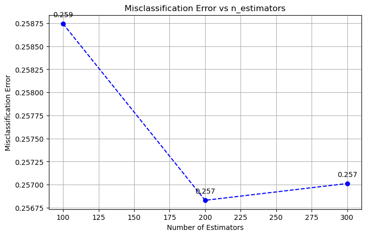

```python
# Misclassification error
misclassification_error = [1 - score for score in cv_scores]
plt.figure(figsize=(8,5))
plt.plot(estimators, misclassification_error, marker='o', linestyle='--', color='b')
for i, txt in enumerate(misclassification_error):
    plt.annotate(f"{txt:.3f}", (estimators[i], misclassification_error[i]),
                 textcoords="offset points", xytext=(0,10), ha='center')
plt.xlabel("Number of Estimators")
plt.ylabel("Misclassification Error")
plt.title("Misclassification Error vs n_estimators")
plt.grid(True)
plt.show()
```

```python
# Train RandomForest with optimal n_estimators
optimal_n = estimators[np.argmax(cv_scores)]
print(f"Optimal n_estimators: {optimal_n}")

rf_model = RandomForestClassifier(n_estimators=optimal_n, random_state=42)
rf_model.fit(X_train, y_train)
```

```
Optimal n_estimators: 200
```

```
RandomForestClassifier(n_estimators=200, random_state=42)
```

```python
# Test the model on testing data
y_pred = rf_model.predict(X_test)
print("Classification Report:")
print(classification_report(y_test, y_pred))
```

```
Classification Report:
              precision    recall  f1-score   support

    negative       0.82      0.89      0.85      2340
     neutral       0.57      0.48      0.52       738
    positive       0.70      0.62      0.66       582

    accuracy                           0.76      3660
   macro avg       0.70      0.66      0.68      3660
weighted avg       0.75      0.76      0.76      3660
```

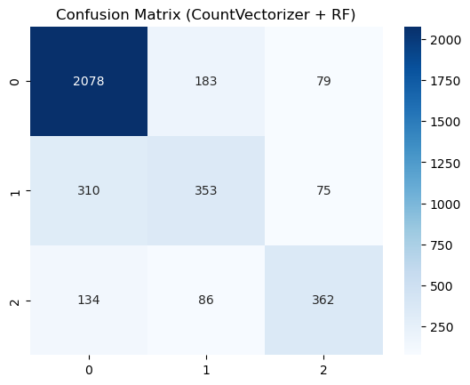

```python
# Plot the Confusion Matrix
cm = confusion_matrix(y_test, y_pred)
sns.heatmap(cm, annot=True, fmt='d', cmap="Blues")
plt.title("Confusion Matrix (CountVectorizer + RF)")
plt.show()
```

- The model is classifying 2,078 out of 2,340 negative tweets correctly (89%), 353 out of 738 neutral tweets correctly (48%), and 362 out of 582 positive tweets correctly (62%)

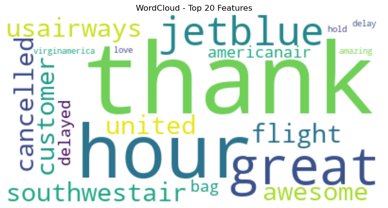

```python
#Plot WordCloud for top 20 important features
features = count_vec.get_feature_names_out()
importances = rf_model.feature_importances_
top_idx = np.argsort(importances)[::-1][:20]
top_words = " ".join([features[i] for i in top_idx])

wc = WordCloud(background_color="white", colormap="viridis").generate(top_words)
plt.figure(figsize=(10,6))
plt.imshow(wc, interpolation="bilinear")
plt.axis("off")
plt.title("WordCloud - Top 20 Features")
plt.show()
```

- Using CountVectorizer, some of the top 20 important features for the Random Forest model include words such as “thank,” “united,” “delayed,” “cancelled,” “customer,” etc. These words are highly indicative of sentiment, with complaint-related words like delayed and cancelled contributing to negative predictions, and words like thank signaling positive sentiment.

### Using TF-IDF (Term Frequency- Inverse Document Frequency)

- Intialize TFIDF and use it for vectorization
- Store Independent and Dependent variables
- Split the data into train and test
- Build a Random Forest model on train data
- Use Cross validation to validate the score and to find optimal n_estimators
- Plot the misclassification error for each of estimators
- Test the model on testing data
- Plot the Confusion matrix plot word cloud for top 20 important features obtained from TFIDF and random forest model

```python
# Initialize TF-IDF and use it for vectorization
tfidf_vec = TfidfVectorizer(max_features=2000)
X_tfidf = tfidf_vec.fit_transform(df_model['clean_text']).toarray()

# Store Independent and Dependent variables
X = X_tfidf   # Independent variable
y = df_model['airline_sentiment'].reset_index(drop=True)  # Dependent variable
targets = sorted(y.unique().tolist())

# Split the data into train and test
X_train, X_test, y_train, y_test = train_test_split(X, y, test_size=0.25, random_state=42, shuffle=True)

# Build a Random Forest model on train data (default n_estimators)
rf_default = RandomForestClassifier(random_state=42)
rf_default.fit(X_train, y_train)
print("Random Forest trained on training data with default n_estimators")
```

```
Random Forest trained on training data with default n_estimators
```

```python
# Cross validation to validate the score and find optimal n_estimators
skf = StratifiedKFold(n_splits=5, shuffle=True, random_state=42)
estimators = [100, 200,300,400]
cv_scores = []

for n in estimators:
    rf = RandomForestClassifier(n_estimators=n, random_state=42)
    scores = cross_val_score(rf, X_train, y_train, cv=skf, scoring='accuracy')
    cv_scores.append(scores.mean())

# Find the best estimator
optimal_n = estimators[np.argmax(cv_scores)]
print(f"Optimal n_estimators = {optimal_n}")
```

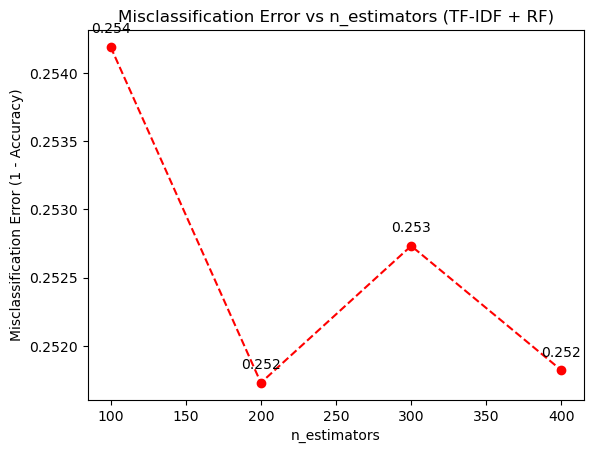

```python
# Plot the misclassification error for each of estimators
errors = [1 - score for score in cv_scores]
plt.plot(estimators, errors, marker='o', linestyle='--', color='r')
for i, err in enumerate(errors):
    plt.annotate(f"{err:.3f}", (estimators[i], err),
                 textcoords="offset points", xytext=(0,10), ha='center')
plt.xlabel("n_estimators")
plt.ylabel("Misclassification Error (1 - Accuracy)")
plt.title("Misclassification Error vs n_estimators (TF-IDF + RF)")
plt.show()
```

```python
# Test the model on testing data (using optimal n_estimators)
rf_tfidf = RandomForestClassifier(n_estimators=optimal_n, random_state=42)
rf_tfidf.fit(X_train, y_train)
y_pred = rf_tfidf.predict(X_test)

print("Classification Report:")
print(classification_report(y_test, y_pred))
```

```
Classification Report:
              precision    recall  f1-score   support

    negative       0.80      0.94      0.86      2340
     neutral       0.65      0.40      0.49       738
    positive       0.73      0.57      0.64       582

    accuracy                           0.77      3660
   macro avg       0.72      0.64      0.66      3660
weighted avg       0.76      0.77      0.75      3660
```

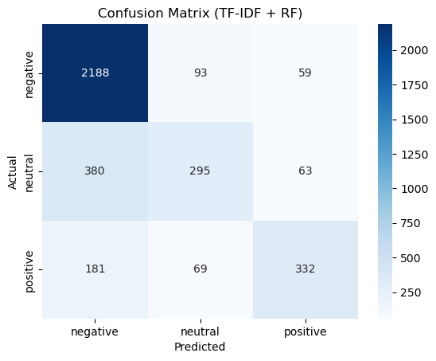

```python
# Plot the Confusion Matrix
cm = confusion_matrix(y_test, y_pred, labels=targets)
sns.heatmap(cm, annot=True, fmt='d', cmap="Blues", xticklabels=targets, yticklabels=targets)
plt.title("Confusion Matrix (TF-IDF + RF)")
plt.xlabel("Predicted")
plt.ylabel("Actual")
plt.show()
```

- The model is classifying 2,188 out of 2,340 negative tweets correctly (94%), 295 out of 738 neutral tweets correctly (40%), and 332 out of 582 positive tweets correctly (57%)

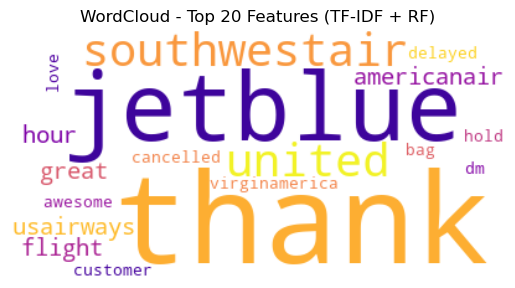

```python
# Plot Word Cloud for top 20 important features
features = tfidf_vec.get_feature_names_out()
importances = rf_tfidf.feature_importances_
top_idx = np.argsort(importances)[::-1][:20]
top_words = " ".join([features[i] for i in top_idx])

wc = WordCloud(background_color="white", colormap="plasma").generate(top_words)
plt.imshow(wc, interpolation="bilinear")
plt.axis("off")
plt.title("WordCloud - Top 20 Features (TF-IDF + RF)")
plt.show()
```

- Using TF-IDF, some of the top 20 important features for the Random Forest model include words such as jetblue, thank, united, southwestair, great, cancelled, etc. These words strongly indicate sentiment: complaint-related words like cancelled contribute to negative predictions, while words like thank signal positive sentiment.

#### Summary of Airline Sentiment Analysis

- Pre-processing:
  - Cleaning tweets reduced noise and highlighted sentiment bearing words like delay, cancelled, great, love.
- Vectorization & Modeling:
  - CountVectorizer and TF-IDF converted text into numeric features for Random Forest.
  - Cross-validation helped select optimal number of trees, stabilizing performance.
- Model Performance:
  - Best accuracy achieved for negative tweets (94%), moderate for positive (62%), and lowest for neutral (40%).
  - Neutral tweets were hardest to classify due to overlapping wording with other sentiments.
- Feature Insights:
  - Confusion matrix showed misclassifications mostly between neutral and negative tweets.
  - Top features (via word cloud) reflected meaningful sentiment words: negative tweets included delay, cancelled, baggage; positive tweets included thanks, great, love.
- Business Implications:
  - TF-IDF + Random Forest achieved slightly higher overall accuracy and performed best for negative tweets, while CountVectorizer + Random Forest performed better for neutral and positive tweets.
  - Airlines can rapidly detect negative sentiment and respond proactively.Airlines can identify parts of customer experience driving sentiment and react faster to negative tweets, improving customer satisfaction and reducing potential business impact.